# Simulation Study III – No Effect

Ryan Shahbaba

2023-06-03

# Simulation Data

This is similar to Simulation II, but this time, we set beta to zero so the gene will not be associated with the outcome variables.

# Method 1 – Integrated Multivariate Regression (IMR)

The first method we are looking at is conducting a principal component analysis [PCA], a data dimension reductionality method, on all the response variables, The first Principal Component [pc1] explains the most variance, so in each simulation, we will extract pc1 as a composite score and use it as the outcome variable in a linear regression model with gene as the explanatory variable.

```r
# Function to calculate the proportion of significant p-values
calculate_prop_significant <- function(n) {
  p_values_pc <- vector("numeric", nsim)

  for (i in 1:nsim) {
    set.seed(i)

    gene <- rbinom(n, 1, 0.25)
    latent <- rnorm(n, 1 + beta * gene, 1)

    y1 <- a[1] + b[1] * latent + rnorm(n, 0, s[1])
    y2 <- a[2] + b[2] * latent + rnorm(n, 0, s[2])
    y3 <- a[3] + b[3] * latent + rnorm(n, 0, s[3])
    y4 <- a[4] + b[4] * latent + rnorm(n, 0, s[4])
    y5 <- a[5] + b[5] * latent + rnorm(n, 0, s[5])

    dataset <- data.frame(y1, y2, y3, y4, y5)
    pc <- prcomp(dataset, center = TRUE, scale. = TRUE)

    pc1 <- pc$x[, 1]

    reg_model_pc <- glm(pc1 ~ gene, data = dataset)

    p_values_pc[i] <- coef(summary(reg_model_pc))[2, "Pr(>|t|)"]
  }

  prop_significant <- mean(p_values_pc < 0.05)
  return(prop_significant)
}

# Vector to store the proportions of significant p-values for each n
pc_prop_significant <- numeric(10)

# Loop through different values of n
for (i in 1:10) {
  n <- 50 * i
  pc_prop_significant[i] <- calculate_prop_significant(n)
}

result_table_pc <- data.frame(Sample_Size = sample_sizes,
                           PC_Prop_Significant = pc_prop_significant)

print(result_table_pc)
```

```
##    Sample_Size PC_Prop_Significant
## 1           50               0.054
## 2          100               0.052
## 3          150               0.053
## 4          200               0.060
## 5          250               0.050
## 6          300               0.052
## 7          350               0.047
## 8          400               0.047
## 9          450               0.052
## 10         500               0.054
```

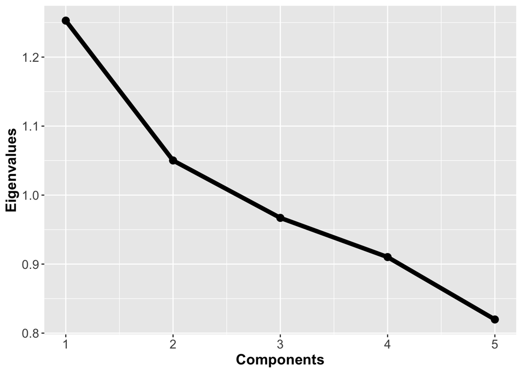

```r
# Scree plot function
screeplot <- function(pc) {
  # Calculate the eigenvalues
  eigenvalues <- pc$sdev^2

  # Calculate the proportion of variance explained
  prop_var <- eigenvalues / sum(eigenvalues)

  # Create a data frame for the scree plot
  scree_data <- data.frame(Components = 1:length(prop_var),
                           Eigenvalues = eigenvalues,
                           Proportion = prop_var)

  # Create the scree plot
  scree_plot <- ggplot(scree_data, aes(x = Components, y = Eigenvalues)) +
    geom_point(size = 3) +
    geom_line(linewidth = 2) +
    ylab("Eigenvalues") +
    xlab("Components") +
    theme(legend.position = "right", axis.text=element_text(size=12),
        axis.title=element_text(size=14,face="bold"),
        legend.text=element_text(size=12),
        legend.title = element_text(size=16))

    #ggtitle("Scree Plot") +
    #theme_minimal()


  # Print the scree plot
  print(scree_plot)
}

set.seed(10)
n <- 500

gene <- rbinom(n, 1, 0.25)
latent <- rnorm(n, 1 + beta * gene, 1)

y1 <- a[1] + b[1] * latent + rnorm(n, 0, s[1])
y2 <- a[2] + b[2] * latent + rnorm(n, 0, s[2])
y3 <- a[3] + b[3] * latent + rnorm(n, 0, s[3])
y4 <- a[4] + b[4] * latent + rnorm(n, 0, s[4])
y5 <- a[5] + b[5] * latent + rnorm(n, 0, s[5])

dataset <- data.frame(y1, y2, y3, y4, y5)
pc <- prcomp(dataset, center = TRUE, scale. = TRUE)

# Call the scree plot function with your variable 'pc'
screeplot(pc)
```

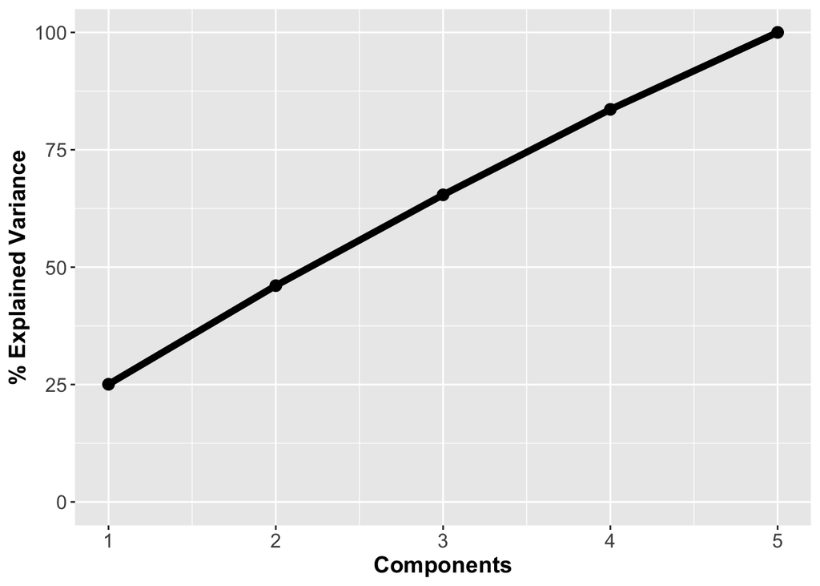

```r
temp <- data.frame(Components=1:ncol(dataset), s=100*cumsum ((pc$sdev^2)/sum(pc$sdev^2)))
ggplot(data=temp, aes(Components, s)) + geom_line(linewidth = 2) +
  geom_point(size = 3) + ylab('% Explained Variance') +
  ylim(0, 100) +
  theme(legend.position = "right", axis.text=element_text(size=12),
        axis.title=element_text(size=14,face="bold"),
        legend.text=element_text(size=12),
        legend.title = element_text(size=16))
```

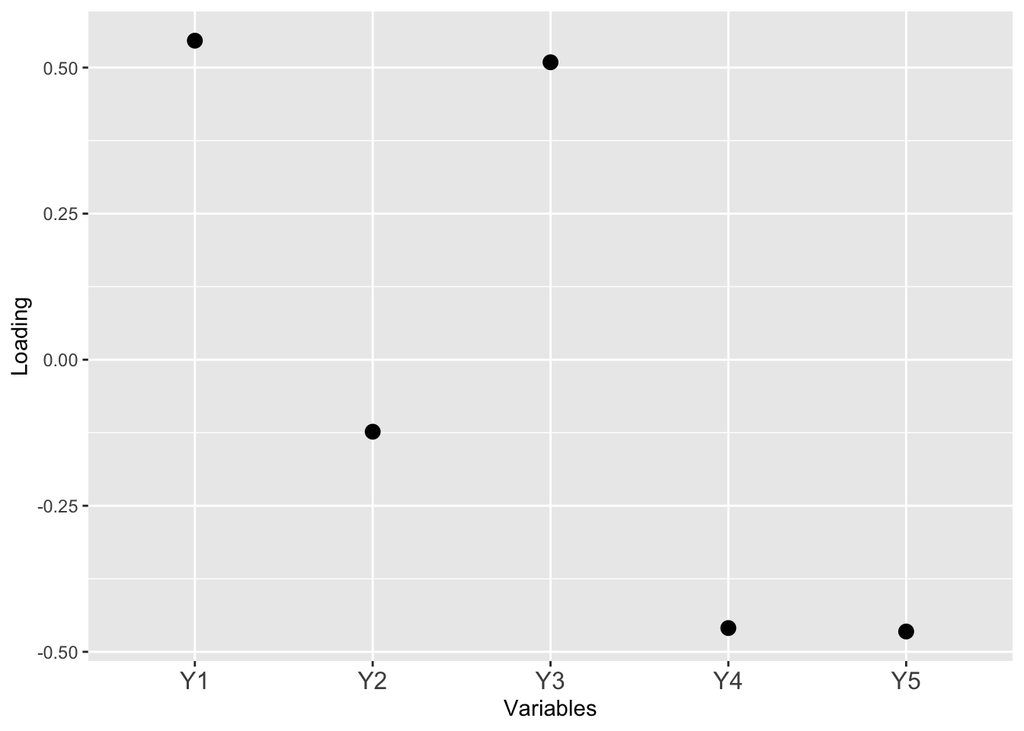

```r
pc_load1 <- data.frame(x = as.factor(seq(1, ncol(dataset))), b = as.vector(pc$rotation[, 1]))
ggplot(data=pc_load1, aes(x=x, y=b)) + geom_point(cex=3) + ylab("Loading") +   #theme(plot.margin = unit(c(1, 1, 3, 1),"lines")) +
  xlab('Variables')+
  scale_x_discrete(labels=c('Y1', 'Y2', 'Y3', 'Y4', 'Y5')) +
  theme(axis.text.x = element_text(size=12))
```

```r
data <- data.frame(y1, y2, y3, y4, y5)

# Compute the correlation matrix
cor_matrix <- cor(data)

# Calculate the eigenvalues
eigen_values <- eigen(cor_matrix)$values

# Print the eigenvalues
print(eigen_values)
```

```
## [1] 1.2528627 1.0502067 0.9669910 0.9101864 0.8197532
```

# Method 2 – Individual Regression Models (IR)

For the second method we run 1000 simulations once again with the same data sets. However this time instead of conducting a PCA, we put each response variable in a separate linear regression model with gene once again as the explanatory variable.

```r
# Initialize variables

linear_prop_significant <- numeric(length(sample_sizes))
adjust_linear_prop_significant <- numeric(length(sample_sizes))

# Perform simulations for each sample size
for (j in 1:length(sample_sizes)) {
  p_values_irm <- matrix(NA, nsim, 5)
  p_values_irma <- matrix(NA, nsim, 5)

  for (i in 1:nsim) {
    set.seed(i)  # Set a different seed for each iteration

    n <- sample_sizes[j]

    gene <- rbinom(n, 1, 0.25)
    latent <- rnorm(n, 1 + beta * gene, 1)


    y1 <- a[1] + b[1] * latent + rnorm(n, 0, s[1])
    y2 <- a[2] + b[2] * latent + rnorm(n, 0, s[2])
    y3 <- a[3] + b[3] * latent + rnorm(n, 0, s[3])
    y4 <- a[4] + b[4] * latent + rnorm(n, 0, s[4])
    y5 <- a[5] + b[5] * latent + rnorm(n, 0, s[5])

    dataset <- data.frame(gene, y1, y2, y3, y4, y5)

    reg_model_y1 <- glm(y1 ~ gene, data = dataset)
    reg_model_y2 <- glm(y2 ~ gene, data = dataset)
    reg_model_y3 <- glm(y3 ~ gene, data = dataset)
    reg_model_y4 <- glm(y4 ~ gene, data = dataset)
    reg_model_y5 <- glm(y5 ~ gene, data = dataset)

    p_values_irm[i, 1] <- coef(summary(reg_model_y1))[2, "Pr(>|t|)"]
    p_values_irm[i, 2] <- coef(summary(reg_model_y2))[2, "Pr(>|t|)"]
    p_values_irm[i, 3] <- coef(summary(reg_model_y3))[2, "Pr(>|t|)"]
    p_values_irm[i, 4] <- coef(summary(reg_model_y4))[2, "Pr(>|t|)"]
    p_values_irm[i, 5] <- coef(summary(reg_model_y5))[2, "Pr(>|t|)"]

    p_values_irma[i, ] <- p.adjust(p_values_irm[i, ], method='holm')

  }

  linear_prop_significant[j] <- mean(p_values_irm < 0.05)
  adjust_linear_prop_significant[j] <- mean(p_values_irma < 0.05)
}



# Print the results
result_table <- data.frame(Sample_Size = sample_sizes,
                           Linear_Prop_Significant = linear_prop_significant, Adjust_Linear_Prop_Significant = adjust_linear_prop_significant)


print(result_table)
```

```
##    Sample_Size Linear_Prop_Significant Adjust_Linear_Prop_Significant
## 1           50                  0.0530                         0.0102
## 2          100                  0.0512                         0.0132
## 3          150                  0.0476                         0.0088
## 4          200                  0.0510                         0.0088
## 5          250                  0.0498                         0.0104
## 6          300                  0.0486                         0.0074
## 7          350                  0.0460                         0.0104
## 8          400                  0.0490                         0.0102
## 9          450                  0.0502                         0.0100
## 10         500                  0.0484                         0.0078
```

# Method 3 – Multivariate Regression (MR)

In this method we once again run the same number of simulations with the same increments of sample sizes, however we conduct a multivariate regression model instead using variables “y1”, “y2” “y3”, “y4”, “y5” as response variables, and gene as the explanatory variable. We then collect all 5 p-values from each regression model and use a MANOVA to obtain the p-value.

```r
# Initialize a vector to store the results
multi_prop_significant <- numeric(10)

# Loop over different values of n
for (j in 1:10) {
  n <- 50 * j  # Change the value of n

  p_values <- vector('numeric', length = nsim)

  for (i in 1:nsim) {
    set.seed(i)

    gene <- rbinom(n, 1, 0.25)
    latent <- rnorm(n, 1 + beta * gene, 1)


    y1 <- a[1] + b[1] * latent + rnorm(n, 0, s[1])
    y2 <- a[2] + b[2] * latent + rnorm(n, 0, s[2])
    y3 <- a[3] + b[3] * latent + rnorm(n, 0, s[3])
    y4 <- a[4] + b[4] * latent + rnorm(n, 0, s[4])
    y5 <- a[5] + b[5] * latent + rnorm(n, 0, s[5])

    dataset <- data.frame(y1, y2, y3, y4, y5, gene)

    reg_model <- lm(cbind(y1, y2, y3, y4, y5) ~ gene, data = dataset)

    anova_result <- anova(reg_model)
    p_values[i] <- anova_result$"Pr(>F)"[2]
  }


  multi_prop_significant[j] <- mean(p_values < 0.05)
}

# Print the results
# print(multi_prop_significant)

result_table_multi <- data.frame(Sample_Size = sample_sizes,
                           Multi_Prop_Significant = multi_prop_significant)

print(result_table_multi)
```

```
##    Sample_Size Multi_Prop_Significant
## 1           50                  0.056
## 2          100                  0.054
## 3          150                  0.044
## 4          200                  0.045
## 5          250                  0.055
## 6          300                  0.054
## 7          350                  0.046
## 8          400                  0.053
## 9          450                  0.056
## 10         500                  0.045
```

# Type I Error Comparison

```r
# Create column names
columns <- c(50, 100, 150, 200, 250, 300, 350, 400, 450, 500)


# Create row names
rows <- c("IMR", "IR", "MR")

# Create an empty matrix
matrix_data <- matrix(nrow = length(rows), ncol = length(columns))
colnames(matrix_data) <- columns
rownames(matrix_data) <- rows

# Assign values to the matrix
matrix_data["IMR", ] <- pc_prop_significant
matrix_data["IR", ] <- linear_prop_significant
matrix_data["MR", ] <- multi_prop_significant
#matrix_data["IRA", ] <- adjust_linear_prop_significant



# Print the matrix
print(matrix_data)
```

```
##        50    100    150   200    250    300   350   400    450    500
## IMR 0.054 0.0520 0.0530 0.060 0.0500 0.0520 0.047 0.047 0.0520 0.0540
## IR  0.053 0.0512 0.0476 0.051 0.0498 0.0486 0.046 0.049 0.0502 0.0484
## MR  0.056 0.0540 0.0440 0.045 0.0550 0.0540 0.046 0.053 0.0560 0.0450
```

```r
matrix_data[, seq(2, 10, 2)] %>% kableExtra::kable()
```

|  | 100 | 200 | 300 | 400 | 500 |
| --- | --- | --- | --- | --- | --- |
| IMR | 0.0520 | 0.060 | 0.0520 | 0.047 | 0.0540 |
| IR | 0.0512 | 0.051 | 0.0486 | 0.049 | 0.0484 |
| MR | 0.0540 | 0.045 | 0.0540 | 0.053 | 0.0450 |

```r
df <- data.frame(x = columns)
for (row in rows) {
  df[row] <- matrix_data[row, ]
}

df <- tidyr::gather(df, Method, value, -x)

df$Method <- factor(df$Method, levels = c('IR', 'MR', 'IMR'))

cbPalette <- c("#999999", "#E69F00", "#56B4E9", "#009E73", "#F0E442", "#0072B2", "#D55E00", "#CC79A7")

# Plot using ggplot2
png(file='null_type_1_error.png')
ggplot(data = df, aes(x = x, y = value, color = Method)) +
  geom_line(linewidth = 2) +
  labs(x = "Sample Size", y = "Type I Error") +
  scale_x_continuous(breaks = columns) +
  ylim(0, 0.2) +
  theme(legend.position = "right", axis.text=element_text(size=16, face="bold"),
        axis.title=element_text(size=18,face="bold"),
        legend.title = element_text(size=20),
        legend.text=element_text(size=18))+
  scale_colour_manual(values=cbPalette)
  geom_hline(yintercept=0.05, linetype="dashed",
                color = "red", size=1)
```

```
## mapping: yintercept = ~yintercept
## geom_hline: na.rm = FALSE
## stat_identity: na.rm = FALSE
## position_identity
```

```r
dev.off()
```

```r
data <- data.frame(y1, y2, y3, y4, y5)

cor_matrix <- cor(data)

print(cor_matrix)
```

```
##             y1          y2          y3          y4          y5
## y1  1.00000000 -0.02598792  0.07523442 -0.08394815 -0.02603108
## y2 -0.02598792  1.00000000 -0.02946869  0.12665668  0.08284144
## y3  0.07523442 -0.02946869  1.00000000 -0.10954326  0.01757364
## y4 -0.08394815  0.12665668 -0.10954326  1.00000000  0.15508116
## y5 -0.02603108  0.08284144  0.01757364  0.15508116  1.00000000
```

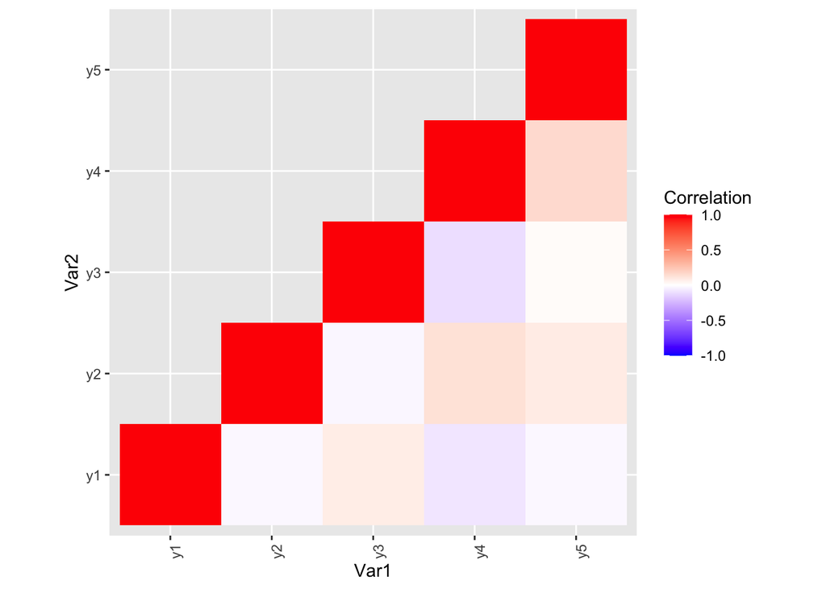

```r
data <- data.frame(y1, y2, y3, y4, y5)

cor_matrix <- cor(data)

# Set upper triangle values to NA
cor_matrix[upper.tri(cor_matrix)] <- NA

# Melt the correlation matrix
melted_cor_matrix <- reshape2::melt(cor_matrix, na.rm = TRUE)

ggplot(data = melted_cor_matrix) +
  geom_tile(aes(x = Var1, y = Var2, fill = value)) +
  scale_fill_gradient2(low = "blue", mid = "white", high = "red",
                       midpoint = 0, limit = c(-1, 1), space = "Lab",
                       name = "Correlation") +
  coord_fixed() +
  theme(axis.text.x = element_text(angle = 90, hjust = 1))
```

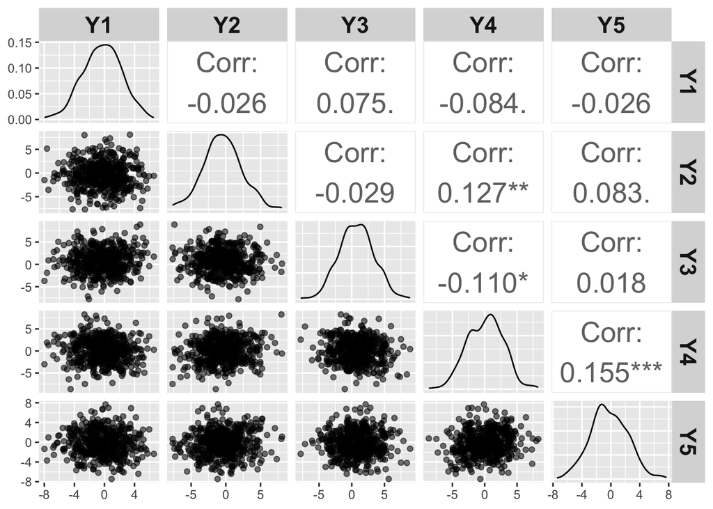

```r
ggpairs(data, aes(alpha = 0.5),
        upper = list(continuous = wrap("cor", size = 7)), columnLabels = c('Y1', 'Y2', 'Y3', 'Y4', 'Y5')) +
  #theme_grey(base_size = 14) +
  theme(axis.title=element_text(face = "bold"))+
  theme(strip.text.x = element_text(size = 16, face='bold'),
           strip.text.y = element_text(size = 16, face='bold'))
```